# Analyzing Data on Health Facilities in Ghana

## SKYHIGH DATA CONSULT LTD

## Overview

We explore the data on the Health Facilities distributed in Ghana to make recommendation to various stakeholders to lend their support in promoting quality healthcare delivery in Ghana through equitable distribution of healthcare facilities and resources.

## Dataset

The Dataset contains 3756 Health Facilities in Ghana. The variables of the dataset are Region, District, Facility Name, Type, Ownership and their Coordinates in Latitude and Longitude.

For a detailed analysis process click [here](https://azubi-project.netlify.app/analysis).  
The repository for the project can be found [here](https://github.com/Mupati/azubi-project)

## Distribution of Health Facilities Per Region

The Ashanti region recorded the most facilities. This was followed by the Greater Accra Region which was closely followed by the Western Region.

Upper West region had the least number of health Facilities.

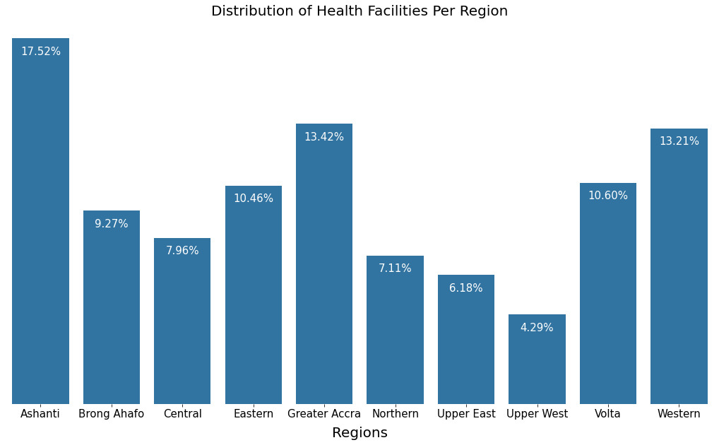

```python
# Distribution of Clinics Per Region
default_color = sb.color_palette()[0]
plt.figure(figsize=[18,10])
sb.countplot(data=clean_df, x='region', color=default_color)


# add annotations
n_points = clean_df.shape[0]
cat_counts = clean_df.region.value_counts()
locs, labels = plt.xticks() # get the current tick locations and labels

# loop through each pair of locations and labels
for loc, label in zip(locs, labels):

    # get the text property for the label to get the correct count
    count = cat_counts[label.get_text()]
    pct_string = '{:0.2f}%'.format(100*count/n_points)

    # print the annotation just below the top of the bar
    plt.text(loc, count-30, pct_string, ha = 'center', color = 'w', fontsize=15)


# plt.ylabel('Number of Health Facilities', fontsize=20)
plt.ylabel('')
plt.xlabel('Regions', labelpad=10, fontsize=20)
plt.title('Distribution of Health Facilities Per Region', fontsize=20)
plt.yticks([])
plt.xticks(fontsize=15)
plt.box(on=None);
```

## Distribution of the Types of Health Facilities.

Most of our facilities are clinics which could mean that most of our facilities cater for just basic health needs of the citizens.

More resources should be allocated to upgrade these facilities into Hospitals to cater for a lot of people

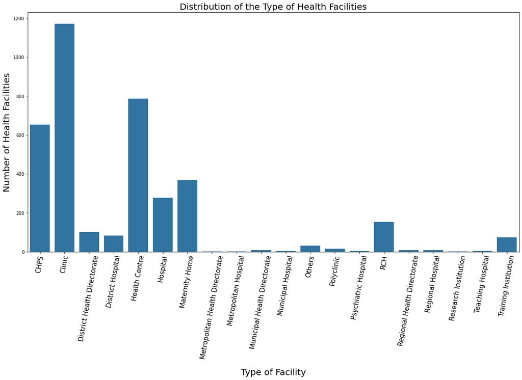

```python
plt.figure(figsize=[20,10])
sb.countplot(data=clean_df, x='type', color=default_color);
plt.xticks(rotation=80, fontsize=15);
plt.xlabel('Type of Facility', labelpad=20, fontsize=20);
plt.ylabel('Number of Health Facilities', fontsize=20);
plt.title('Distribution of the Type of Health Facilities', fontsize=20);
```

## Ownership of Health Facilities

Most of the health facilities are owned by the Government. This followed by the Private ones. There should be policies in place to encourage other players too.

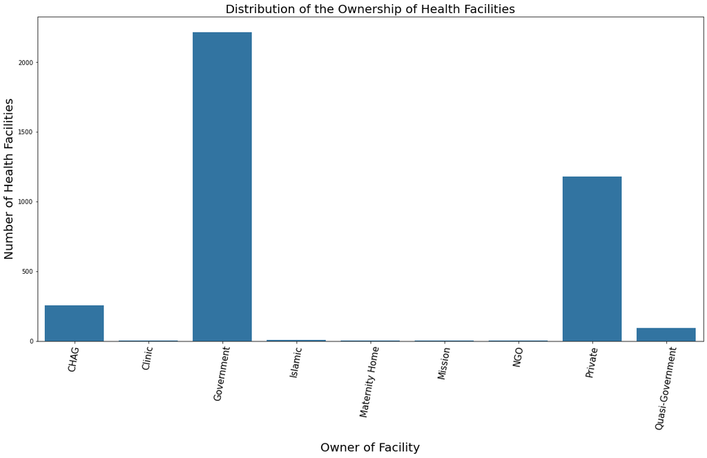

```python
plt.figure(figsize=[20,10])
sb.countplot(data=clean_df, x='ownership', color=default_color);
plt.xticks(rotation=80, fontsize=15);
plt.xlabel('Owner of Facility', labelpad=20, fontsize=20);
plt.ylabel('Number of Health Facilities', fontsize=20);
plt.title('Distribution of the Ownership of Health Facilities', fontsize=20);
```

# Regional Distribution of Health Facility Ownership

As observed early on, most of the health facilities were owned by the Government. The following observations stood out when we look at ownership of health facilities across the regions

- We observe that most of the Health Facilities in the 2 major regions of Ghana, i.e Ashanti and Greater Accra were Privately owned.

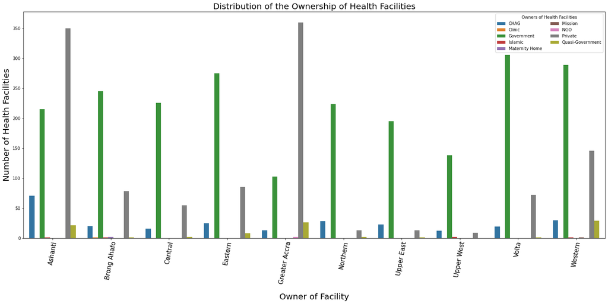

```python
plt.figure(figsize=[25,10])
ax = sb.countplot(data=clean_df, x='region', hue='ownership');


plt.xticks(rotation=80, fontsize=15);
plt.xlabel('Owner of Facility', labelpad=20, fontsize=20);
plt.ylabel('Number of Health Facilities', fontsize=20);
plt.title('Distribution of the Ownership of Health Facilities', fontsize=20);
ax.legend(title='Owners of Health Facilities',loc = 1, ncol = 2);
```

# Distribution of Type of Health Facilities Per Owners.

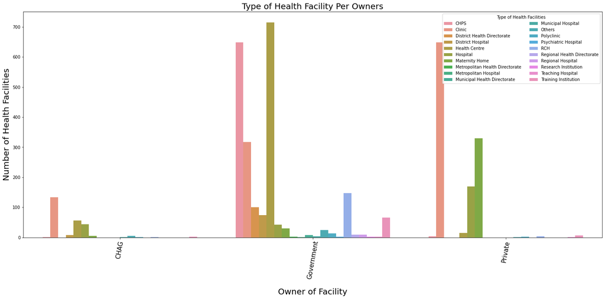

```python
plt.figure(figsize=[25,10])
ax = sb.countplot(data=clean_df, x='ownership', hue='type', order=['CHAG','Government', 'Private']);


plt.xticks(rotation=80, fontsize=15);
plt.xlabel('Owner of Facility', labelpad=20, fontsize=20);
plt.ylabel('Number of Health Facilities', fontsize=20);
plt.title('Type of Health Facility Per Owners', fontsize=20);
ax.legend(title='Type of Health Facilities',loc = 1, ncol = 2);
```

### Distribution of Health Facilities Across the Country

- In the Ashanti and Greater Accra regions, we see a lot of health facilities clustered within specific areas on the map. In both regions, the clusters are within the Capital Towns of both regions, ie. Accra and Kumasi.

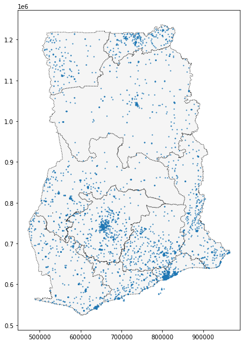

```python
regions = geopandas.read_file('./Map_of_Regions_in_Ghana.shx')
ax = regions.plot(figsize=(10,10), color='whitesmoke', linestyle=':', edgecolor='black')
gdf.to_crs(epsg=32630).plot(markersize=1, ax=ax, label='Distribution of Health Facilities Across Ghana');
```

### Private Health Facilities

Most of the Private Health facilities are located in Kumasi and Accra. The possible reason is that they are more economically viable in these places than other parts of Ghana.

Since the Government is not able to build health facilities across the whole country, they need to incentivize the Private players to be able to reach other parts of the country.

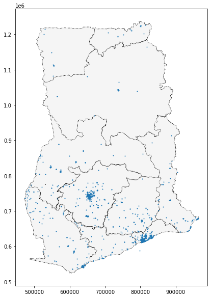

```python
## Distribution of Private Health Facilities
private_facilities = gdf.query('ownership == "Private"');

## Map of Private-owned Health Facilities
ax = regions.plot(figsize=(10,10), color='whitesmoke', linestyle=':', edgecolor='black')
private_facilities.to_crs(epsg=32630).plot(markersize=1,
                                           ax=ax, label='Distribution of Health Facilities Across Ghana');
```

## Health Facilities Across Ashanti Region

```python
IFrame(src='./Ashanti_map.html',width=800, height=700)
```

[interactive chart not shown]

## Health Facilities Across Brong Ahafo Region

```python
IFrame(src='./Brong_Ahafo_map.html',width=800, height=700)
```

[interactive chart not shown]

## Health Facilities Across Central Region

```python
IFrame(src='./Central_map.html',width=800, height=700)
```

[interactive chart not shown]

## Health Facilities Across Eastern Region

```python
IFrame(src='./Eastern_map.html',width=800, height=700)
```

[interactive chart not shown]

## Health Facilities Across Greater Accra Region

```python
IFrame(src='./Greater_Accra_map.html',width=800, height=700)
```

[interactive chart not shown]

## Health Facilities Across Northern Region

```python
IFrame(src='./Northern_map.html',width=800, height=700)
```

[interactive chart not shown]

## Health Facilities Across Upper East Region

```python
IFrame(src='./Upper_East_map.html',width=800, height=700)
```

[interactive chart not shown]

## Health Facilities Across Upper West Region

```python
IFrame(src='./Upper_West_map.html',width=800, height=700)
```

[interactive chart not shown]

## Health Facilities Across Volta Region

```python
IFrame(src='./Volta_map.html',width=800, height=700)
```

[interactive chart not shown]

## Health Facilities Across Western Region

```python
IFrame(src='./Western_map.html',width=800, height=700)
```

[interactive chart not shown]

## Conclusion

We admit that the population distribution according to regions and districts will improve the quality of the suggestions we have given and also help us understand the reason for the various distributions we observe.

Ghana has made strides over the years to improve healthcare delivery and with our observations and suggestions we will be able to work at improving the health care in Ghana, not only in the Quantity of Health facilities but the Quality as well.

Copyright 2020, SKYHIGH DATA CONSULT LTD.